# R Notebook

# Pearson Chi-Quadrat-Test | Cramers V

# A. Aufgabe: Der Chi-Quadrat-Test mit R | Cramers´V OHNE ANPASSUNG

Eine Studie untersucht, ob sich die Studierendenbereitschaft nach einem Auslandjahr sich verändert. Vor dem Auslandjahr wurde die Studieninteressierte befragt, bzw. nach dem Auslandjahr. Jetzt stellt sich die Frage: Gibt es einen Zusammenhang zwischen vor und nach dem Ausjahrs in Punkto der Studienbereitschaft?

Der zu analysierende Datensatz enthält neben einer Befragtennummer (ID), (Studierbereitschaft vorher), (Studierbereitschaft nachher).

## 1. Hypothese:

H1: Es gibt einen Zusammmenhang zwischen der Studierbereitschaft vor dem Auslandsjahr und der Studierbereitschaft nach dem Auslandsjahr.

H0: Es gibt keinen Zusammmenhang zwischen der Studierbereitschaft vor dem Auslandsjahr und der Studierbereitschaft nach dem Auslandsjahr.

## 2. Voraussetzungen:

Die Variablen sind kategorial (nominal- oder ordinalskaliert)

### 2.1. Datensatz:

```r
library(readxl)
chi <- read_xlsx("chi.xlsx")
chi
```

| ID | vorher | nachher |
| --- | --- | --- |
| 1 | hoch | hoch |
| 2 | hoch | hoch |
| 3 | hoch | hoch |
| 4 | hoch | hoch |
| 5 | hoch | hoch |
| 6 | hoch | hoch |
| 7 | niedrig | hoch |
| 8 | niedrig | hoch |
| 9 | niedrig | hoch |
| 10 | niedrig | hoch |

[output cut: 35 more lines]

## 3. Balkendiagramm:

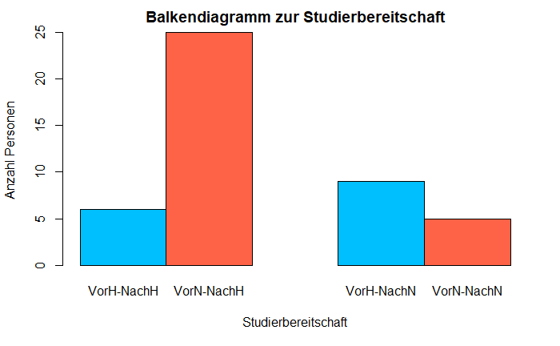

```r
counts <- table(chi$vorher, by = chi$nachher)

barplot(counts, main="Balkendiagramm zur Studierbereitschaft", col=c("deepskyblue","tomato"),
        ylab="Anzahl Personen", xlab = "Studierbereitschaft", beside=T,
        names.arg =c("VorH-NachH","VorN-NachH","VorH-NachN", "VorN-NachN"))
```

## 4. Kreuztabelle:

```r
counts
```

```
         by
          hoch niedrig
  hoch       6       9
  niedrig   25       5
```

```r
counts<- table(Vorher = chi$vorher, nachher = chi$nachher)
print("beobachtete Werte ")
```

```
[1] "beobachtete Werte "
```

```r
print(counts)
```

```
         nachher
Vorher    hoch niedrig
  hoch       6       9
  niedrig   25       5
```

Die Tabelle wurde angelegt.

## 5. Erwarteten Werte:

```r
ch <- chisq.test(counts, correct = F)
```

```
Chi-squared approximation may be incorrect
```

```r
print("Erwartete Werte ")
```

```
[1] "Erwartete Werte "
```

```r
ch
```

```
    Pearson's Chi-squared test

data:  counts
X-squared = 8.7615, df = 1, p-value = 0.003077
```

```r
round(ch$expected, 2)
```

```
         nachher
Vorher     hoch niedrig
  hoch    10.33    4.67
  niedrig 20.67    9.33
```

Die beobachteten und die erwarteten Werte wurden verglichen. Es zeigen sich für das Beispiel einen Unterschiede. Ob es jedoch signifikant sind, wird mittels Chi-Quadrat-Test geprüft.

## 6. X²:

$$\chi^2 = \sum^I_{i=1}\sum^J_{j=1}\frac{(f_{ij}-f^{'}_{ij})^2}{f^{'}_{ij}}$$

```r
ch <- chisq.test(counts, correct = F)
```

```
Chi-squared approximation may be incorrect
```

```r
ch
```

```
    Pearson's Chi-squared test

data:  counts
X-squared = 8.7615, df = 1, p-value = 0.003077
```

Der Test bestätigt, dass ein Zusammenhang zwischen Studierbereitschaft vor der Auslandsjahr und die Studierbereitschaft nach denm Auslandsjahr besteht (Chi-Quadrat(1) = 8.7615, p = .003077).

## 7. Cramers ´V :

** Die Zahl 2 steht für 2×2 Design.**

```r
anzahl <- nrow(chi)

sprintf("Der Datensatz hat %d Zeilen.",anzahl)
```

```
[1] "Der Datensatz hat 45 Zeilen."
```

```r
cramersV <- sqrt(( ch$statistic)/(anzahl*(2-1)))
sprintf("Die Effektstärke liegt bei %.2f.", cramersV)
```

```
[1] "Die Effektstärke liegt bei 0.44."
```

Cramer s V ist immer positiv. Es wird keine Aussage über die Richtung des Zusammenhangs gemacht.

Es zeigt sich für unsere Auswertung, dass ein mittlerer Zusammenhang besteht.

## 8. Aussage:

Die Studierbereitschaft vor dem Auslandsjahr und die Studierbereitschaft nach dem Auslandsjahr stehen in einem Zusammenhang (Chi-Quadrat(1) = 8.7615 p = .003077, n= 45). Der Zusammenhang ist mittlerer (Cramers V = .44). Damit kann die H0 verworfen werden.

# B. Aufgabe: Der Chi-Quadrat-Test mit R | Cramers´V MIT ANPASSUNG:

## 1. Hypothese:

H1: Es gibt einen Zusammmenhang zwischen der Studierbereitschaft vor dem Auslandsjahr und der Studierbereitschaft nach dem Auslandsjahr.

H0: Es gibt keinen Zusammmenhang zwischen der Studierbereitschaft vor dem Auslandsjahr und der Studierbereitschaft nach dem Auslandsjahr.

## 2. Vorausetzungen:

Die Variablen sind kategorial (nominal- oder ordinalskaliert)

** Datensatzgröße**

1. Die Stichprobe ist > 50.
2. Ist dies nicht der Fall, so wird bei einer Stichprobe kleiner als 20 der exakte Test nach Fisher verwendet
3. bei einer Stichprobengröße zwischen 20 und 50 die Korrektur nach Yates.

| Fall | Fisher | Yates |
| --- | --- | --- |
| Fall 1 | - | - |
| Fall 2 | - | + |
| Fall 3 | + | - |
| Fall 4 | + | + |

#### Die erwarteten Zellhäufigkeiten sind > 5. Ist dies nicht der Fall, so wird der exakte Test nach Fisher verwendet.

#### Die Freiheitsgrade des Chi-Quadrat-Tests sind größer als 1. Ist dies nicht der Fall, so wird die Korrektur nach Yates verwendet.

### 2.1. Datensatz:

```r
head(chi, 5)
```

[output not shown]

## 3. Balkendiagramm:

```r
counts<- table(Vorher= chi$vorher, Nachher = chi$nachher)

barplot(counts, main="Balkendiagramm zur Studierbereitschaft", col=c("deepskyblue","tomato"),
        ylab="Anzahl Personen", xlab = "Studierbereitschaft", beside=T,
        names.arg =c("VorH-NachH","VorN-NachH","VorH-NachN", "VorN-NachN"), legend = rownames(counts),
        args.legend = list(x = "topright"))
```

[output not shown]

## 4. Kreuztabelle und Beobachteten Werte:

```r
counts<- table( Vorher =chi$vorher, Nachher = chi$nachher)
head(counts)
```

[output not shown]

Die Tabelle wurde angelegt.

## 5. Erwarteten Werte:

```r
ch <- chisq.test(counts, correct = F)
```

```
Chi-squared approximation may be incorrect
```

```r
round(ch$expected, 2)
```

```
         Nachher
Vorher     hoch niedrig
  hoch    10.33    4.67
  niedrig 20.67    9.33
```

Die beobachteten und die erwarteten Werte wurden verglichen. Es zeigen sich für das Beispiel einen Unterschiede. Ob es jedoch signifikant sind, wird mittels Chi-Quadrat-Test geprüft.

## 6. Ergebnis zum X² und Prüfung der Signifikanz:

### 1) Die Stichprobe ist > 50.

```r
ch <- chisq.test(counts, correct = F)
```

```
Chi-squared approximation may be incorrect
```

```r
ch
```

```
    Pearson's Chi-squared test

data:  counts
X-squared = 8.7615, df = 1, p-value = 0.003077
```

Bericht:(Chi-Quadrat(1) = 8.7615, p = .003077)

### 2) Ist dies nicht der Fall, so wird bei einer Stichprobe kleiner als 20 der exakte Test nach Fisher verwendet.

```r
ch <- chisq.test(counts, correct = F)
```

```
Chi-squared approximation may be incorrect
```

```r
ch
```

```
    Pearson's Chi-squared test

data:  counts
X-squared = 8.7615, df = 1, p-value = 0.003077
```

```r
fisher.test(counts)
```

```
    Fisher's Exact Test for Count Data

data:  counts
p-value = 0.005673
alternative hypothesis: true odds ratio is not equal to 1
95 percent confidence interval:
 0.02562454 0.66353638
sample estimates:
odds ratio
 0.1409759
```

Bericht:(Chi-Quadrat(1) = 8.7615, p = .005673)

### 3) bei einer Stichprobengröße zwischen 20 und 50 die Korrektur nach Yates.

```r
ch <- chisq.test(counts, correct = TRUE)
```

```
Chi-squared approximation may be incorrect
```

```r
ch
```

```
    Pearson's Chi-squared test with Yates' continuity correction

data:  counts
X-squared = 6.8563, df = 1, p-value = 0.008833
```

Bericht:(Chi-Quadrat(1) = 6.8563, p = .008833)

#### Die erwarteten Zellhäufigkeiten sind > 5. Ist dies nicht der Fall, so wird der exakte Test nach Fisher verwendet.

#### Die Freiheitsgrade des Chi-Quadrat-Tests sind größer als 1. Ist dies nicht der Fall, so wird die Korrektur nach Yates verwendet.

In dieser Übung ist es notwending nach Fisher und nach Yates zu korregieren. Daher wird folgender Code verwendet.

```r
ch <- chisq.test(counts, correct = TRUE)
```

```
Chi-squared approximation may be incorrect
```

```r
ch
```

```
    Pearson's Chi-squared test with Yates' continuity correction

data:  counts
X-squared = 6.8563, df = 1, p-value = 0.008833
```

```r
fisher.test(counts)
```

```
    Fisher's Exact Test for Count Data

data:  counts
p-value = 0.005673
alternative hypothesis: true odds ratio is not equal to 1
95 percent confidence interval:
 0.02562454 0.66353638
sample estimates:
odds ratio
 0.1409759
```

Hinweise: Da in dieser Übungsaufgabe der exakte Test nach Fisher verwendet werden muss, wird nicht folgender p-value = 0.008833 zitiert, sondern Fisher mit einem p-value von 0.005673.

Der Test bestätigt, dass ein Zusammenhang zwischen Studierbereitschaft vor dem Auslandsjahr und die Studierbereitschaft nach dem Auslandsjahr besteht (Chi-Quadrat(1) = 6.8563, p = .005673).

## 7. Cramers ´V:

```r
anzahl <- nrow(chi)

sprintf("Der Datensatz hat %d Zeilen.",anzahl)
```

```
[1] "Der Datensatz hat 45 Zeilen."
```

```r
sprintf("Das Chi-Quadrat liegt bei %.2f.",ch$statistic)
```

```
[1] "Das Chi-Quadrat liegt bei 6.86."
```

```r
cramersV <- sqrt(( ch$statistic)/(anzahl*(2-1)))
sprintf("Die Effektstärke liegt bei %.2f.",cramersV)
```

```
[1] "Die Effektstärke liegt bei 0.39."
```

Cramer s V ist immer positiv -> keine Aussage über die Richtung des Zusammenhangs

Es zeigt sich für unsere Auswertung, dass ein mittlerer Zusammenhang besteht.

## 8. Aussage:

Die Studierbereitschaft vor dem Auslandsjahr und die Studierbereitschaft nach dem Auslandsjahr stehen in einem Zusammenhang (Chi-Quadrat(1) = 6.8563, p = .005673, n= 45). Der Zusammenhang ist mittelstark (Cramers V = .4). Damit kann die H0 verworfen werden.

# HINWEIS FUR ANPASSUNG:

### Fall 1

$$\chi^2 = \sum^I_{i=1}\sum^J_{j=1}\frac{(f_{ij}-f^{'}_{ij})^2}{f^{'}_{ij}}$$

**keine Anpassung erforderlich**

```r
ch <- chisq.test(counts, correct = F) # correct = F ohne Anpassungen - die "normale" Formel
ch
```

```
    Pearson's Chi-squared test

data:  counts
X-squared = 8.7615, df = 1, p-value = 0.003077
```

**Bericht:**(Chi-Quadrat(1) = 8.7615, p = .003077)

### Fall 2

**Anpassung: Korrektur nach Yates**

$$\chi^2 = \sum^I_{i=1}\sum^J_{j=1}\frac{(\Bigl| f_{ij}-f^{'}_{ij}\Bigl| -0.5)^2}{f^{'}_{ij}}$$

```r
ch <- chisq.test(counts, correct = TRUE) # Die Anpassung nach Yates - correct = TRUE - Die Formel wird um -0.5 erweietert
ch
```

```
    Pearson's Chi-squared test with Yates' continuity correction

data:  counts
X-squared = 6.8563, df = 1, p-value = 0.008833
```

**Bericht:**(Chi-Quadrat(1) = 6.8563, p = .008833)

### Fall 3

**Anpassung: Fisher’s Exact Test**

```r
ch <- chisq.test(counts, correct = F)
ch
```

```
    Pearson's Chi-squared test

data:  counts
X-squared = 8.7615, df = 1, p-value = 0.003077
```

```r
fisher.test(counts)
```

```
    Fisher's Exact Test for Count Data

data:  counts
p-value = 0.005673
alternative hypothesis: true odds ratio is not equal to 1
95 percent confidence interval:
 0.02562454 0.66353638
sample estimates:
odds ratio
 0.1409759
```

**Bericht:**(Chi-Quadrat(1) = 8.7615, p = .005673)

### Fall 4

**Anpassung: Fisher’s Exact Test & Anpassung nach Yates**

**3) bei einer Stichprobengröße zwischen 20 und 50 die Korrektur nach Yates.**

*Die erwarteten Zellhäufigkeiten sind > 5. Ist dies nicht der Fall, so wird der exakte Test nach Fisher verwendet.**

**Die Freiheitsgrade des Chi-Quadrat-Tests sind größer als 1. Ist dies nicht der Fall, so wird die Korrektur nach Yates verwendet.**

```r
ch <- chisq.test(counts, correct = TRUE)
ch
```

```
    Pearson's Chi-squared test with Yates' continuity correction

data:  counts
X-squared = 6.8563, df = 1, p-value = 0.008833
```

```r
fisher.test(counts)
```

```
    Fisher's Exact Test for Count Data

data:  counts
p-value = 0.005673
alternative hypothesis: true odds ratio is not equal to 1
95 percent confidence interval:
 0.02562454 0.66353638
sample estimates:
odds ratio
 0.1409759
```

**Hinweise**: Da in dieser Übungsaufgabe der exakte Test nach Fisher verwendet werden muss, wird nicht folgender **p-value = 0.008833** zitiert, sondern Fisher mit einem p-value von **0.005673**.

Der Test bestätigt, dass ein Zusammenhang zwischen Studierbereitschaft vor dem Auslandsjahr und die Studierbereitschaft nach dem Auslandsjahr besteht (Chi-Quadrat(1) = 6.8563, p = .005673).